# The distribution of sample means obtained from an exponential distribution

Jae Wook Lee

October 23, 2015

## Overview

In this document, the properties of sample means obtained from an exponential distribution are analyzed in terms of their relationship to the population mean and variance.

## Simulations

The following R code simulates sampling of 1000 sets of 40 exponentials. The rate parameter for the exponential distribution (lambda) is set to 0.2.

```r
lambda = 0.2   # rate for the exponential distribution
nosim=1000     # number of simulations
n = 40         # size of a sample
samples = replicate(nosim, mean(rexp(n, rate=lambda)))  # a vector of 1000 sample means
```

## Sample mean versus Theoretical Mean

The mean of the sample means are 4.9886349. It is almost equal to the population mean 5. In the following code, we can see that the mean of the sample means approaches the theoretical mean as the number of simulation grows.

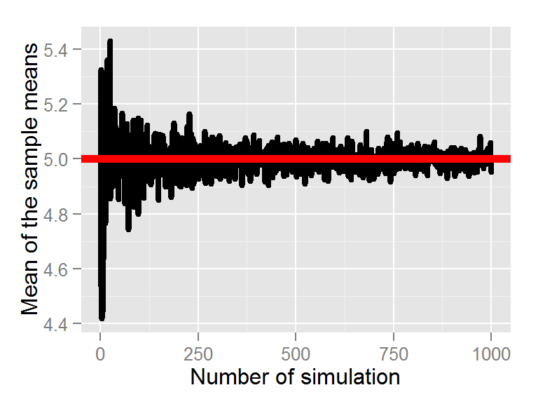

```r
means <- sapply(1:nosim, function(x) mean(replicate(x, mean(rexp(n, lambda)))))
require(ggplot2)
g <- ggplot(data.frame(x = 1 : nosim, y = means), aes(x = x, y = y)) + geom_line(size=1.5)
g <- g + geom_hline(yintercept = 1/lambda, col="red", size=2)
g <- g + labs(x = "Number of simulation", y = "Mean of the sample means")
g
```

## Sample variance vs Theoretical variance

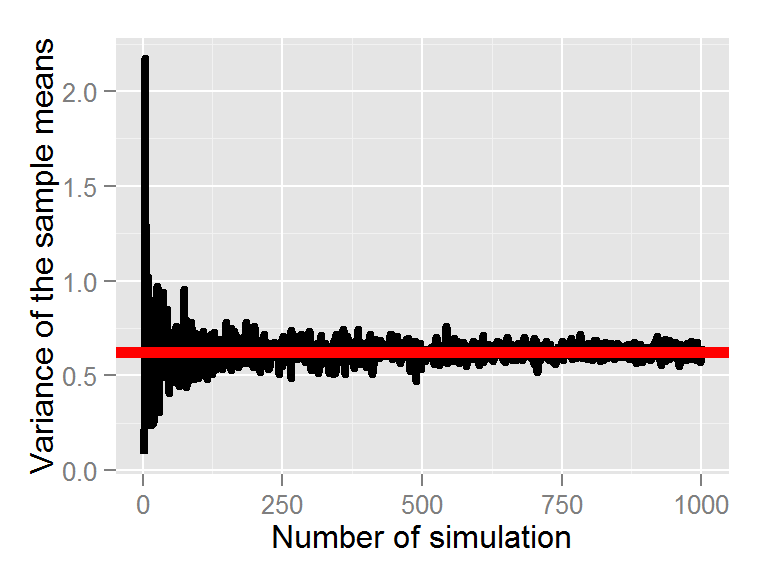

## The distribution of 1000 sample means is approximately normal.

The histogram for the sample means shows that they approximate a normal distribution with a mean of 1/lambda and standard deviation of (1/lambda)/(sqrt(n)).

```
## stat_bin: binwidth defaulted to range/30. Use 'binwidth = x' to adjust this.
```

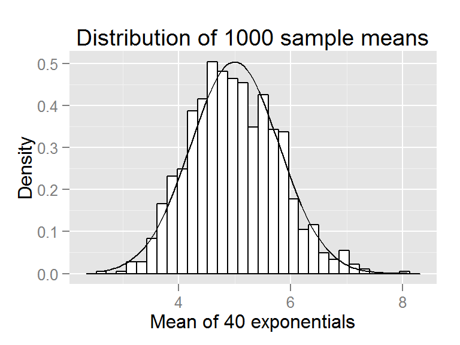

The quantile-quantile plot below also shows that 1000 samples means are normally distributed.

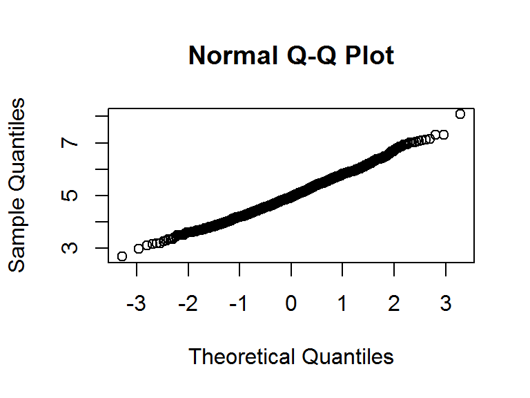